# Ark spectra

Justin Pomeranz

12/27/2021

## Overview

Preliminary analyses for Arkansas Size Spectra project

Not shown: stitching all of the CSVs together, adding length-weight regression coefficients and estimating dry weight (dw) measurements

```r
dw <- readRDS("data/ark_dw.RDS")
head(dw)
```

[output not shown]

## “Bin” the data based on body size

### Size spectra

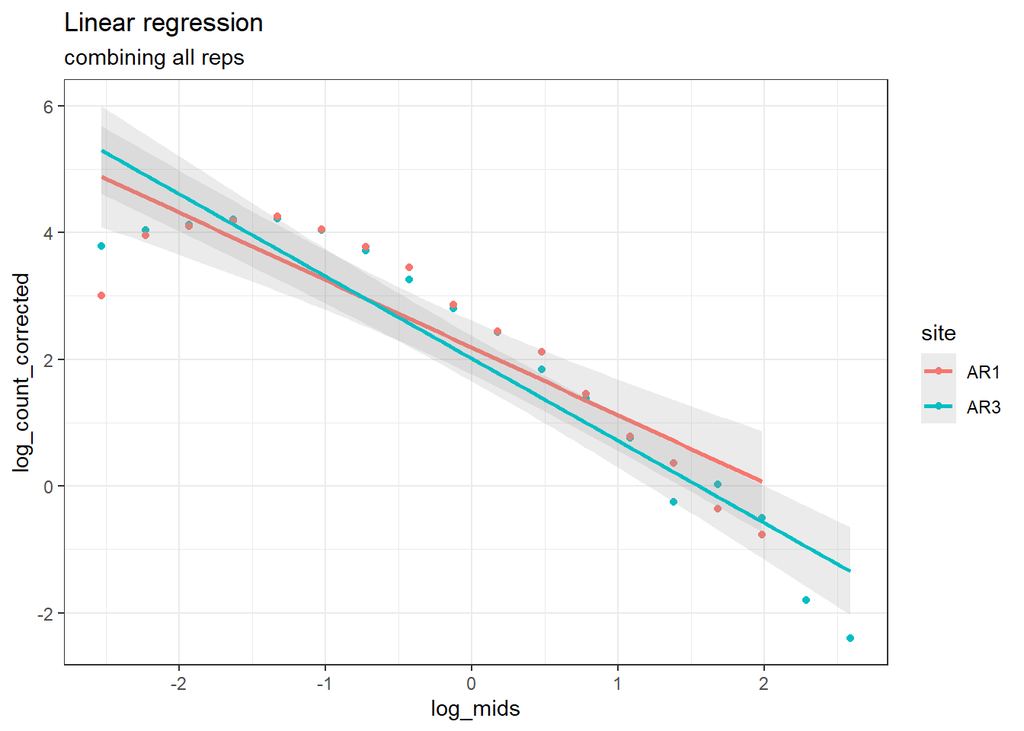

This looks really good! I’m surprised that the slopes are so similar, but this is pretty much exactly what we would expect size spectra relationships to look like.

## Stats for above plot

We can look at the values of the size spectra by running a simple linear regression

```r
summary(lm_mod)
```

```
##
## Call:
## lm(formula = log_count_corrected ~ log_mids_center * site, data = bin)
##
## Residuals:
##     Min      1Q  Median      3Q     Max
## -1.8756 -0.4552  0.1702  0.6055  0.8193
##
## Coefficients:
##                         Estimate Std. Error t value Pr(>|t|)
## (Intercept)               2.6390     0.1879  14.047 9.90e-15 ***
## log_mids_center          -1.0663     0.1346  -7.922 7.67e-09 ***
## siteAR3                  -0.4617     0.2581  -1.789   0.0837 .
## log_mids_center:siteAR3  -0.2323     0.1756  -1.323   0.1958
## ---
## Signif. codes:  0 '***' 0.001 '**' 0.01 '*' 0.05 '.' 0.1 ' ' 1
##
## Residual standard error: 0.7471 on 30 degrees of freedom
## Multiple R-squared:  0.8691, Adjusted R-squared:  0.856
## F-statistic: 66.38 on 3 and 30 DF,  p-value: 2.388e-13
```

This is showing us that there is no difference between the two sites. As I said, this is surprising to me, but this is still a pretty incredible result; the aquatic communities here have similar biomass structures, despite profound (?) differences in community composition and chemical attributes.

## Other analyses

Because we are looking at a “small” range of body sizes (i.e., only macroinvertebrates), it is recommended to fit quadratic relationships and compare the explanatory power:

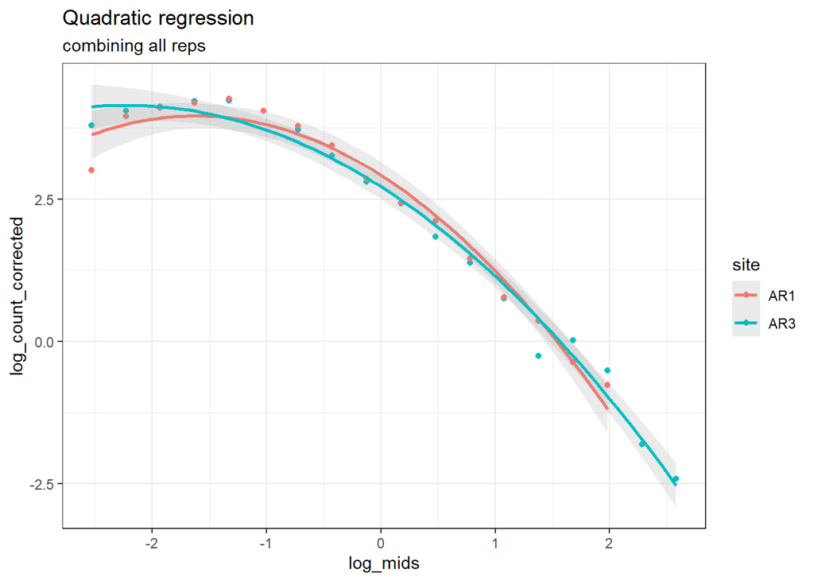

```r
summary(quad_mod)
```

```
##
## Call:
## lm(formula = log_count_corrected ~ log_mids_center * site + I(log_mids_center^2),
##     data = bin)
##
## Residuals:
##      Min       1Q   Median       3Q      Max
## -0.83986 -0.15847  0.00247  0.22395  0.50761
##
## Coefficients:
##                         Estimate Std. Error t value Pr(>|t|)
## (Intercept)              3.26049    0.09176  35.531  < 2e-16 ***
## log_mids_center         -0.96796    0.05547 -17.451  < 2e-16 ***
## siteAR3                 -0.29405    0.10612  -2.771  0.00965 **
## I(log_mids_center^2)    -0.32656    0.02654 -12.304 4.92e-13 ***
## log_mids_center:siteAR3 -0.23229    0.07160  -3.244  0.00296 **
## ---
## Signif. codes:  0 '***' 0.001 '**' 0.01 '*' 0.05 '.' 0.1 ' ' 1
##
## Residual standard error: 0.3047 on 29 degrees of freedom
## Multiple R-squared:  0.979,  Adjusted R-squared:  0.976
## F-statistic: 337.2 on 4 and 29 DF,  p-value: < 2.2e-16
```

## Including variation between reps

The results shown above are combining all of the reps (surbers) together, essentially giving us one estimate of the community composition per site.

Interestingly, when I bin the data separately within each rep and use these to estimate the size spectra we get slightly different results for both the linear and the quadratic analysis:

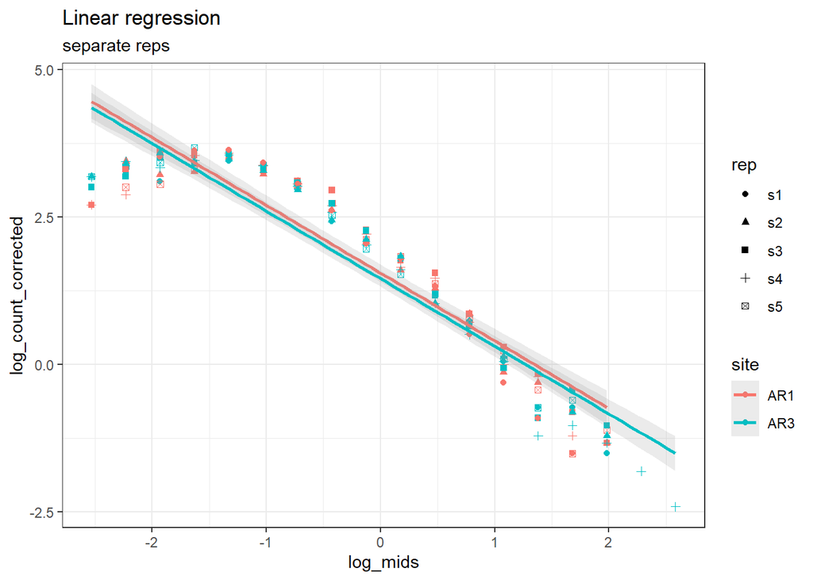

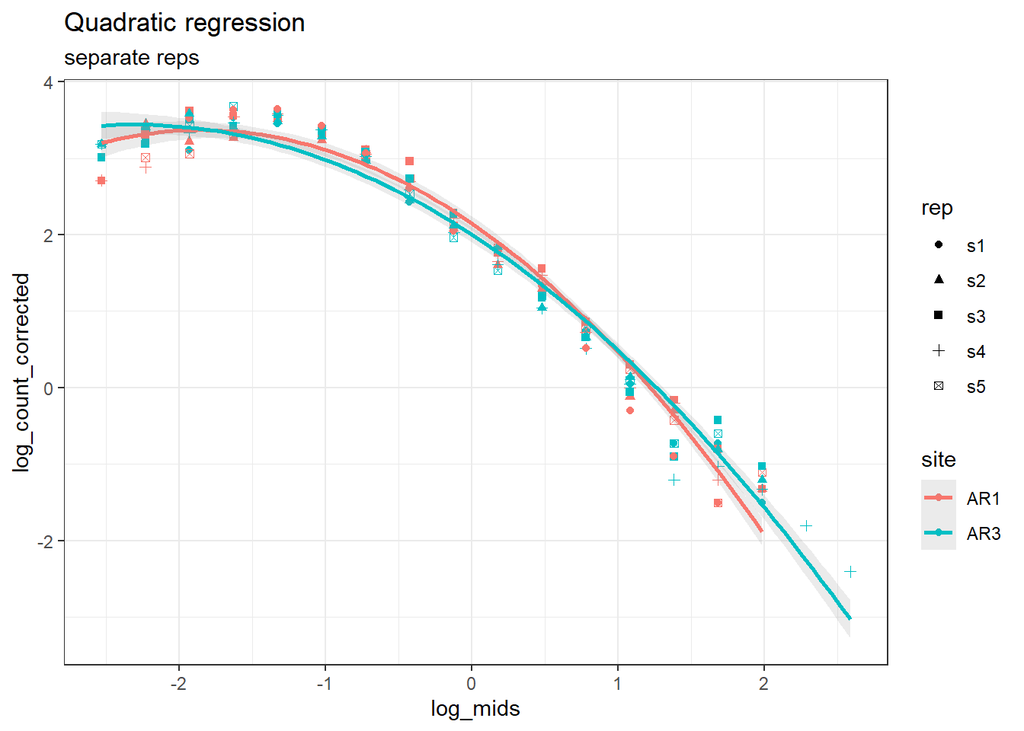

```r
summary(rep.lm)
```

```
##
## Call:
## lm(formula = log_count_corrected ~ log_mids_center * site, data = bin)
##
## Residuals:
##     Min      1Q  Median      3Q     Max
## -1.6053 -0.4842  0.1573  0.5471  1.0554
##
## Coefficients:
##                          Estimate Std. Error t value Pr(>|t|)
## (Intercept)              1.904593   0.074001  25.737   <2e-16 ***
## log_mids_center         -1.143669   0.056595 -20.208   <2e-16 ***
## siteAR3                 -0.035894   0.102849  -0.349    0.728
## log_mids_center:siteAR3  0.001724   0.075474   0.023    0.982
## ---
## Signif. codes:  0 '***' 0.001 '**' 0.01 '*' 0.05 '.' 0.1 ' ' 1
##
## Residual standard error: 0.6402 on 152 degrees of freedom
## Multiple R-squared:  0.8599, Adjusted R-squared:  0.8571
## F-statistic: 310.9 on 3 and 152 DF,  p-value: < 2.2e-16
```

```r
summary(rep.quad)
```

```
##
## Call:
## lm(formula = log_count_corrected ~ log_mids_center * site + I(log_mids_center^2),
##     data = bin)
##
## Residuals:
##     Min      1Q  Median      3Q     Max
## -1.4113 -0.2015  0.0317  0.2402  0.8098
##
## Coefficients:
##                         Estimate Std. Error t value Pr(>|t|)
## (Intercept)              2.43253    0.04958  49.064   <2e-16 ***
## log_mids_center         -1.10585    0.03124 -35.398   <2e-16 ***
## siteAR3                  0.05889    0.05688   1.035    0.302
## I(log_mids_center^2)    -0.31012    0.01658 -18.707   <2e-16 ***
## log_mids_center:siteAR3  0.05504    0.04167   1.321    0.189
## ---
## Signif. codes:  0 '***' 0.001 '**' 0.01 '*' 0.05 '.' 0.1 ' ' 1
##
## Residual standard error: 0.3526 on 151 degrees of freedom
## Multiple R-squared:  0.9578, Adjusted R-squared:  0.9566
## F-statistic: 855.9 on 4 and 151 DF,  p-value: < 2.2e-16
```

## So which analysis?

Great question, and the short answer is: I don’t know! There is actually a bit of an open question on whether or not size spectra are best estimated by combining all the data (first results above) or using different samples (surbers) to estimate the relationship.

## next samples?

This might be worth having a meeting to discuss.

### season?

One question I have beforehand is wich season were these samples from? Spring or summer? – One option would be to try other seasons from this same year to see if there are seasonal differences. My instinct is that Spring would have the greatest differences, but I could be wrong, especially if spring samples are pre-runoff.

### AR1 impacts?

Also, I believe Will said that AR1 might have also been impacted at the beginning of the study; are these samples after the restoration of LMDT occured? Are there samples of AR1 post-LMDT restoration but pre-CA gulch restoration? – Sampling in this “window” might reveal greater differences between the two sites

### longitudinal effects?

Impacts lower down at AR4 or 5? I don’t think this is likely, but the longitudinal effects may be more pronounced i.e., AR3 might be close enough to the unimpacted sites that individuals are drifting down and inflating the size spectra relationship

### Post restoration samples

Despite there not being profound differences pre-restoration, I still think that it would be a good idea to process some post-retoration sites from more recent years, 2018 or 19? – One thing we may need to figure out is if/how the subsampling routine affects estimates of size spectra. This might be possible using analytical techniques (i.e. me playing around with the data you already sent), or require a more robust pilot study (i.e., process the subsampled invertebrates, then complete a full-pick of the remaining sample which was not subsampled)

### ID to genus?

One thing I just thought of is that IDing everything to family may not be sensitive enough to detect differences. I think this is unlikely, and I could probably look at some of my old data to see if the taxonomic level makes a difference, but I mention it here for reference.